# chapter 2

Min-Yao

```r
library("rstan") # observe startup messages
options(mc.cores = parallel::detectCores())
rstan_options(auto_write = TRUE)
Sys.setenv(LOCAL_CPPFLAGS = '-march=native')
```

# Chapter 0

## R code 0.1

```r
print( "All models are wrong, but some are useful." )
```

```
## [1] "All models are wrong, but some are useful."
```

## R code 0.2

```r
x <- 1:2
x
```

```
## [1] 1 2
```

```r
x <- x*10
x
```

```
## [1] 10 20
```

```r
x <- log(x)
x
```

```
## [1] 2.302585 2.995732
```

```r
x <- sum(x)
x
```

```
## [1] 5.298317
```

```r
x <- exp(x)
x
```

```
## [1] 200
```

## R code 0.3

```r
( log( 0.01^200 ) )
```

```
## [1] -Inf
```

```r
( 200 * log(0.01) )
```

```
## [1] -921.034
```

## R code 0.4

#### Load the data:

#### car braking distances in feet paired with speeds in km/h

#### see ?cars for details

```r
data(cars)
```

#### fit a linear regression of distance on speed

```r
m <- lm( dist ~ speed , data=cars )
```

#### estimated coefficients from the model

```r
coef(m)
```

```
## (Intercept)       speed
##  -17.579095    3.932409
```

#### plot residuals against speed

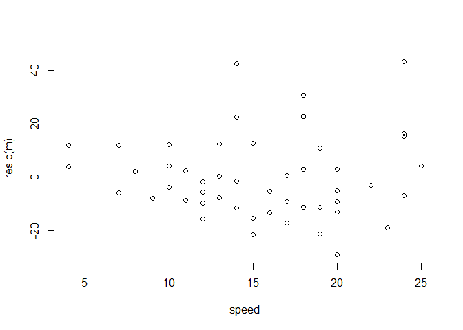

```r
plot( resid(m) ~ speed , data=cars )
```

## R code 0.5

```r
#install.packages(c("coda","mvtnorm","devtools"))
library(devtools)
#devtools::install_github("rmcelreath/rethinking",ref="Experimental")
```

# Chapter 2

## R code 2.1

```r
ways <- c( 0 , 3 , 8 , 9 , 0 )
ways/sum(ways)
```

```
## [1] 0.00 0.15 0.40 0.45 0.00
```

## R code 2.2

```r
dbinom( 6 , size=9 , prob=0.5 )
```

```
## [1] 0.1640625
```

## R code 2.3

#### define grid

```r
p_grid <- seq( from=0 , to=1 , length.out=20 )
```

#### define prior

```r
prior <- rep( 1 , 20 )
```

#### compute likelihood at each value in grid

```r
likelihood <- dbinom( 6 , size=9 , prob=p_grid )
```

#### compute product of likelihood and prior

```r
unstd.posterior <- likelihood * prior
```

#### standardize the posterior, so it sums to 1

```r
posterior <- unstd.posterior / sum(unstd.posterior)
```

## R code 2.4

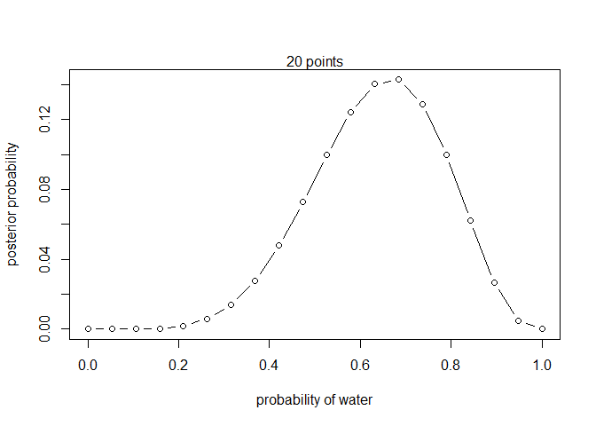

```r
plot( p_grid , posterior , type="b" ,
    xlab="probability of water" , ylab="posterior probability" )
mtext( "20 points" )
```

## R code 2.5

```r
prior <- ifelse( p_grid < 0.5 , 0 , 1 )
prior <- exp( -5*abs( p_grid - 0.5 ) )
```

## R code 2.6

```r
library(rethinking)
library(parallel)
globe.qa <- quap(
    alist(
        W ~ dbinom( W+L ,p) ,  # binomial likelihood
        p ~ dunif(0,1)     # uniform prior
    ) ,
    data=list(W=6,L=3) )
```

# display summary of quadratic approximation

```r
precis( globe.qa )
```

```
##        mean        sd      5.5%     94.5%
## p 0.6666671 0.1571337 0.4155371 0.9177971
```

## R code 2.7

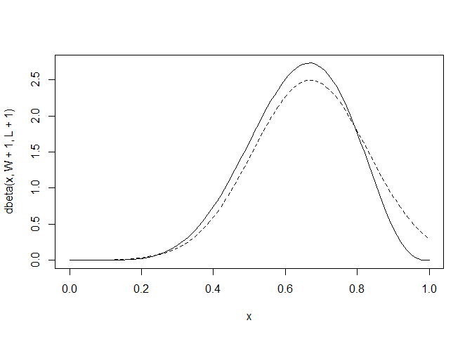

```r
# analytical calculation
W <- 6
L <- 3
curve( dbeta( x , W+1 , L+1 ) , from=0 , to=1 )

# quadratic approximation
curve( dnorm( x , 0.67 , 0.16 ) , lty=2 , add=TRUE )
```

## R code 2.8

```r
n_samples <- 1000
p <- rep( NA , n_samples )
p[1] <- 0.5
W <- 6
L <- 3
for ( i in 2:n_samples ) {
    p_new <- rnorm( 1 , p[i-1] , 0.1 )
    if ( p_new < 0 ) p_new <- abs( p_new )
    if ( p_new > 1 ) p_new <- 2 - p_new
    q0 <- dbinom( W , W+L , p[i-1] )
    q1 <- dbinom( W , W+L , p_new )
    p[i] <- ifelse( runif(1) < q1/q0 , p_new , p[i-1] )
}
```

## R code 2.9

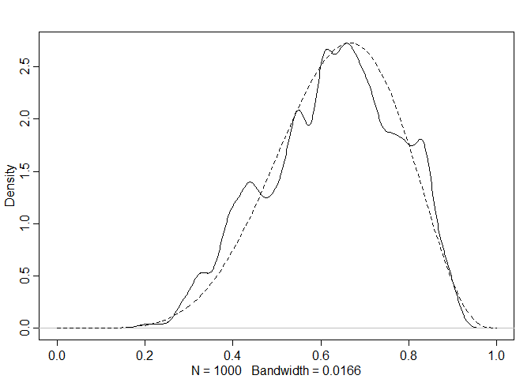

```r
dens( p , xlim=c(0,1) )
curve( dbeta( x , W+1 , L+1 ) , lty=2 , add=TRUE )
```

### 2E1 Which of the expressions below correspond to the statement: the probability of rain on Monday?

2. Pr(rain|Monday) & (4) Pr(rain, Monday)/ Pr(Monday)

### 2E2 Which of the following statements corresponds to the expression: Pr(Mondayjrain)?

3. Th e probability that it is Monday, given that it is raining.

### 2E3 Which of the expressions below correspond to the statement: the probability that it is Monday, given that it is raining?

1. Pr(Monday|rain) & (4) Pr(rain|Monday) Pr(Monday)/ Pr(rain)

### 2M1-(1) Recall the globe tossing model from the chapter. Compute and plot the grid approximate posterior distribution for each of the following sets of observations. In each case, assume a uniform prior for p.

1. W, W, W
2. W, W, W, L
3. L, W, W, L, W, W, W

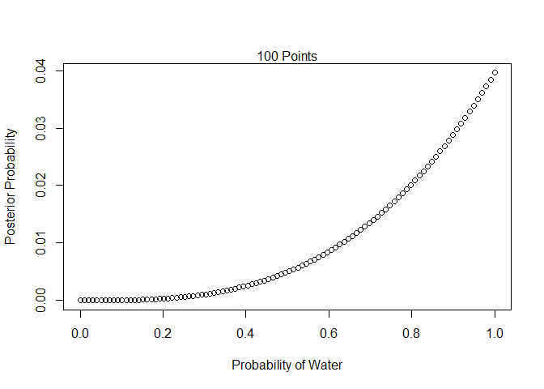

```r
data1 <- c('W','W','W')
# total number of tosses
n = length(data1)
# observed number of water
w = sum(data1=='W')

# define grid
p_grid <- seq( from=0 , to=1 , length.out=100)
length_of_grid = length(p_grid)
# prior probability of p
prior <- rep( 1 , length_of_grid )

# compute likelihood at each value in grid
likelihood <- dbinom( w , size=n , prob=p_grid )

# compute product of likelihood and prior
unstd.posterior <- likelihood * prior

# standardize the posterior, so it sums to 1
posterior <- unstd.posterior / sum(unstd.posterior)

plot_posterior <- function(x, y) {
  plot(x = x, y = y, type="b", xlab = "Probability of Water", ylab = "Posterior Probability")
  title <- paste( length(x), "Points")
  mtext(title)
}
plot_posterior(x = p_grid, y = posterior)
```

### 2M1-(2)

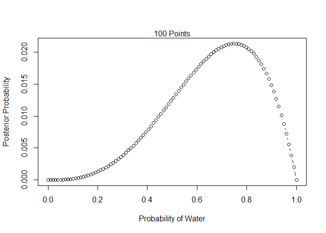

```r
data1 <- c('W','W','W','L')
# total number of tosses
n = length(data1)
# observed number of water
w = sum(data1=='W')

# define grid
p_grid <- seq( from=0 , to=1 , length.out=100)
length_of_grid = length(p_grid)
# prior probability of p
prior <- rep( 1 , length_of_grid )

# compute likelihood at each value in grid
likelihood <- dbinom( w , size=n , prob=p_grid )

# compute product of likelihood and prior
unstd.posterior <- likelihood * prior

# standardize the posterior, so it sums to 1
posterior <- unstd.posterior / sum(unstd.posterior)

plot_posterior(x = p_grid, y = posterior)
```

### 2M1-(3)

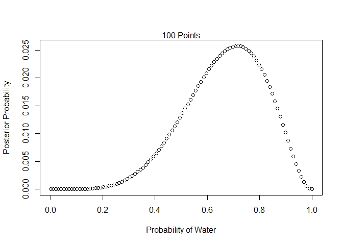

```r
data1 <- c('L', 'W', 'W', 'L', 'W', 'W', 'W')
# total number of tosses
n = length(data1)
# observed number of water
w = sum(data1=='W')

# define grid
p_grid <- seq( from=0 , to=1 , length.out=100)
length_of_grid = length(p_grid)
# prior probability of p
prior <- rep( 1 , length_of_grid )

# compute likelihood at each value in grid
likelihood <- dbinom( w , size=n , prob=p_grid )

# compute product of likelihood and prior
unstd.posterior <- likelihood * prior

# standardize the posterior, so it sums to 1
posterior <- unstd.posterior / sum(unstd.posterior)

plot_posterior(x = p_grid, y = posterior)
```

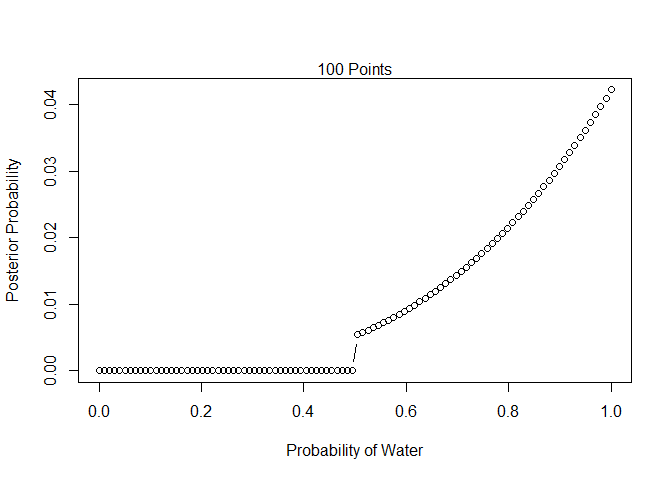

```r
data1 <- c('W','W','W')
# total number of tosses
n = length(data1)
# observed number of water
w = sum(data1=='W')

# define grid
p_grid <- seq( from=0 , to=1 , length.out=100)
length_of_grid = length(p_grid)

# prior probability of p
prior <- ifelse( p_grid < 0.5 , 0 , 1 )

# compute likelihood at each value in grid
likelihood <- dbinom( w , size=n , prob=p_grid )

# compute product of likelihood and prior
unstd.posterior <- likelihood * prior

# standardize the posterior, so it sums to 1
posterior <- unstd.posterior / sum(unstd.posterior)

plot_posterior <- function(x, y) {
  plot(x = x, y = y, type="b", xlab = "Probability of Water", ylab = "Posterior Probability")
  title <- paste( length(x), "Points")
  mtext(title)
}
plot_posterior(x = p_grid, y = posterior)
```

### 2M2-(2)

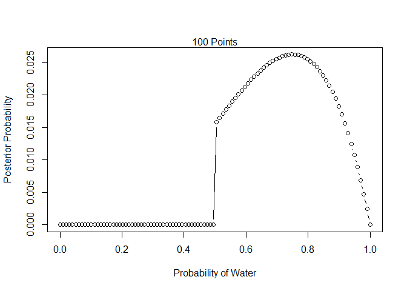

```r
data1 <- c('W','W','W','L')
# total number of tosses
n = length(data1)
# observed number of water
w = sum(data1=='W')

# define grid
p_grid <- seq( from=0 , to=1 , length.out=100)
length_of_grid = length(p_grid)

# prior probability of p
prior <- ifelse( p_grid < 0.5 , 0 , 1 )

# compute likelihood at each value in grid
likelihood <- dbinom( w , size=n , prob=p_grid )

# compute product of likelihood and prior
unstd.posterior <- likelihood * prior

# standardize the posterior, so it sums to 1
posterior <- unstd.posterior / sum(unstd.posterior)

plot_posterior(x = p_grid, y = posterior)
```

### 2M2-(3)

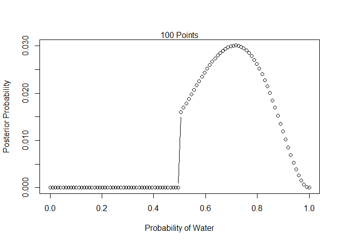

```r
data1 <- c('L', 'W', 'W', 'L', 'W', 'W', 'W')
# total number of tosses
n = length(data1)
# observed number of water
w = sum(data1=='W')

# define grid
p_grid <- seq( from=0 , to=1 , length.out=100)
length_of_grid = length(p_grid)

# prior probability of p
prior <- ifelse( p_grid < 0.5 , 0 , 1 )

# compute likelihood at each value in grid
likelihood <- dbinom( w , size=n , prob=p_grid )

# compute product of likelihood and prior
unstd.posterior <- likelihood * prior

# standardize the posterior, so it sums to 1
posterior <- unstd.posterior / sum(unstd.posterior)

plot_posterior(x = p_grid, y = posterior)
```

### 2M3. Suppose there are two globes, one for Earth and one for Mars. Th e Earth globe is 70% covered in water. Th e Mars globe is 100% land. Further suppose that one of these globes?Xyou don??t know which?Xwas tossed in the air and produced a ??land?? observation. Assume that each globe was equally likely to be tossed. Show that the posterior probability that the globe was the Earth, conditional on seeing ??land?? (Pr(Earthjland)), is 0.23.

```r
# p(Earth) and p(Mars)
p_Earth = 0.5
p_Mars = 0.5

# p(land|Earth) and p(land|Mars)
p_land_E = 0.3
p_land_M = 1.0

# p(land)
p_land = p_Earth*p_land_E + p_Mars*p_land_M
p_land
```

```
## [1] 0.65
```

```r
# p(Earth|land) = (p(land|Earth) * p(Earth)) / p(land)
p_Earth_land = (p_land_E * p_Earth)/p_land
p_Earth_land
```

```
## [1] 0.2307692
```

### other methods

```r
prior <- c(0.5 , 0.5) # first is for earth, second is for mars
prob <- c(0.7, 0) # prob of water for earth, and for mars
likelihood <- dbinom(0, 1, prob) # likelihood for earth and for mars
unstd.post <- likelihood * prior
post <- unstd.post / sum(unstd.post)
post
```

```
## [1] 0.2307692 0.7692308
```

### 2M4. Suppose you have a deck with only three cards. Each card has two sides, and each side is either black or white. One card has two black sides. Th e second card has one black and one white side. The third card has two white sides. Now suppose all three cards are placed in a bag and shuffl ed. Someone reaches into the bag and pulls out a card and places it fl at on a table. A black side is shown facing up, but you don??t know the color of the side facing down. Show that the probability that the other side is also black is 2/3. Use the counting method (Section 2 of the chapter) to approach this problem. Th is means counting up the ways that each card could produce the observed data (a black side facing up on the table).

```r
# Use the counting method
BB.likelihood <- 2
BW.likelihood <- 1
WW.likelihood <- 0

likelihood <- c(BB.likelihood, BW.likelihood, WW.likelihood)

# prior probability
prior <- rep(1, length = length(likelihood))

# compute product of likelihood and prior
unstd.posterior <- likelihood * prior

# standardize the posterior, so it sums to 1
posterior <- unstd.posterior / sum(unstd.posterior)
posterior
```

```
## [1] 0.6666667 0.3333333 0.0000000
```

```r
posterior[1] == 2/3
```

```
## [1] TRUE
```

$$P(2=B|1=B) = P(2=B,1=B) / P(1=B) = P(BB) / (P(BB) + P(WB) * P(1=B|WB)) = (1/3) / (1/3 + 1/3 * 1/2) = 2/3 = 0.667$$

### 2M5. Now suppose there are four cards: B/B, B/W, W/W, and another B/B. Again suppose a card is drawn from the bag and a black side appears face up. Again calculate the probability that the other side is black.

```r
# Use the counting method
BB.likelihood <- 2
BW.likelihood <- 1
WW.likelihood <- 0

likelihood2 <- c(BB.likelihood, BW.likelihood, WW.likelihood, BB.likelihood)

# prior probability
prior <- rep(1, length = length(likelihood2))

# compute product of likelihood and prior
unstd.posterior <- likelihood2 * prior

# standardize the posterior, so it sums to 1
posterior <- unstd.posterior / sum(unstd.posterior)
posterior
```

```
## [1] 0.4 0.2 0.0 0.4
```

```r
# we may draw card 1 or 4
result = posterior[1]+posterior[4]
result
```

```
## [1] 0.8
```

$$P(2=B|1=B) = P(2=B,1=B) / P(1=B) = P(BB) / (P(BB) + P(WB)*P(1=B|WB)) = (1/2) / (1/2 + 1/4 * 1/2) = 4/5 = 0.8$$

### 2H1. Suppose there are two species of panda bear. Both are equally common in the wild and live in the same places. Th ey look exactly alike and eat the same food, and there is yet no genetic assay capable of telling them apart. Th ey diff er however in their family sizes. Species A gives birth to twins 10% of the time, otherwise birthing a single infant. Species B births twins 20% of the time, otherwise birthing singleton infants. Assume these numbers are known with certainty, from many years of fi eld research.

```r
prior <- c(0.5 , 0.5)
prob <- c(0.1, 0.2)
#likelihood <- dbinom(2, 2, prob)
unstd.post <- prob * prior
unstd.post
```

```
## [1] 0.05 0.10
```

```r
post <- unstd.post / sum(unstd.post)
post
```

```
## [1] 0.3333333 0.6666667
```

```r
twins.prob.given.twins <- post * prob
twins.prob.given.twins
```

```
## [1] 0.03333333 0.13333333
```

```r
sum(twins.prob.given.twins)
```

```
## [1] 0.1666667
```